# Lab 1 Write-up

Erica Chen

```r
#Import the data
spring_2020_lab_1_data <- read.csv("spring_2020_lab_1_data.csv", header = T)
#Attach the data
attach(spring_2020_lab_1_data)
```

##### Exercise 1: Comparing BHSEC to the rest of the country

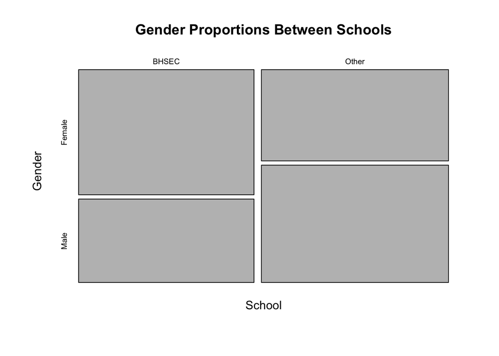

```r
plot(table(School,Gender), main="Gender Proportions Between Schools", xlab="School", ylab="Gender")
```

In this question, I will examine whether or not there is an association between gender and schools. I predict the two variables (school and gender) to be associated because there is a low possibility for a school to have genders perfectly split. Moreover, when walking down the halls, to get an idea of the general population, I notice there are more females than males. The two-way table above supports my hypothesis that gender and school are associated. According to the table, in BHSEC there is a greater female population (area of the square) than male compared to “other schools”. In other words, less than 50% of BHSEC is made up of males, while the remaining majority are in fact females. The opposite goes for the population in other schools. Another aspect of the mosaic table that suggests the lack of association is noting the area of each square within the mosaic table but more specifically where the borders cut off to form the different sized areas. If the area of the sections were all equally distributed, the conclusion would be that the variables are independent of each other. However, in this dataset, if I were to take both variables and switch them, the data would not remain the same therefore making the variables depend on each other.

##### Exercise 2: Comparing BHSEC to the rest of the country (part 2)

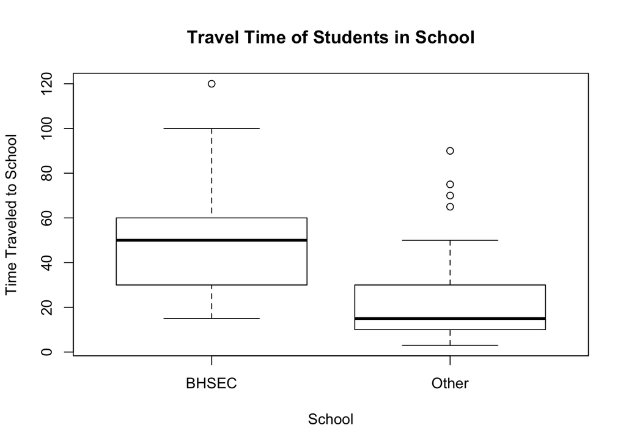

```r
boxplot((Travel_time_to_School~School), main="Travel Time of Students in School", xlab = "School", ylab= "Time Traveled to School")
```

In this question, I will analyze whether or not there is an association between the travel time of students in school and schools. I predict the two variables (travel time and school) to be associated because the urban area of BHSEC makes the commute unique compared to other schools. If anything, I expect the travel time for students at BHSEC to be longer than other schools because of how often local trains stop and factoring in trains/bus transfers and other factors specific to the urban environment. My prediction was supported because the boxplot above shows the differing relationship between the median travel time of students at BHSEC versus other school’s travel time to school. In fact, both the median and interquartile range of both boxplots do not overlap. The spread of BHSEC student’s travel time to school is also greater than that of other schools. I assume this is the case because there are students coming from farther boroughs such as The Bronx and deeper Brooklyn, which requires a longer commute. According to the BHSEC boxplot, there is an unusual recording around 120 minutes for travel time to school, which may explain student(s) that live in New Jersy and/or Long Island. However, in other schools, the data shows four times the number of outliers. There are many aspects of the data that present a dependent relationship.

##### Exercise 3: Writing your own research question

In this question, I will ask whether or not there an association between the longer finger on the left hand and longer foot in the male population then comparing this with the BHSEC population.

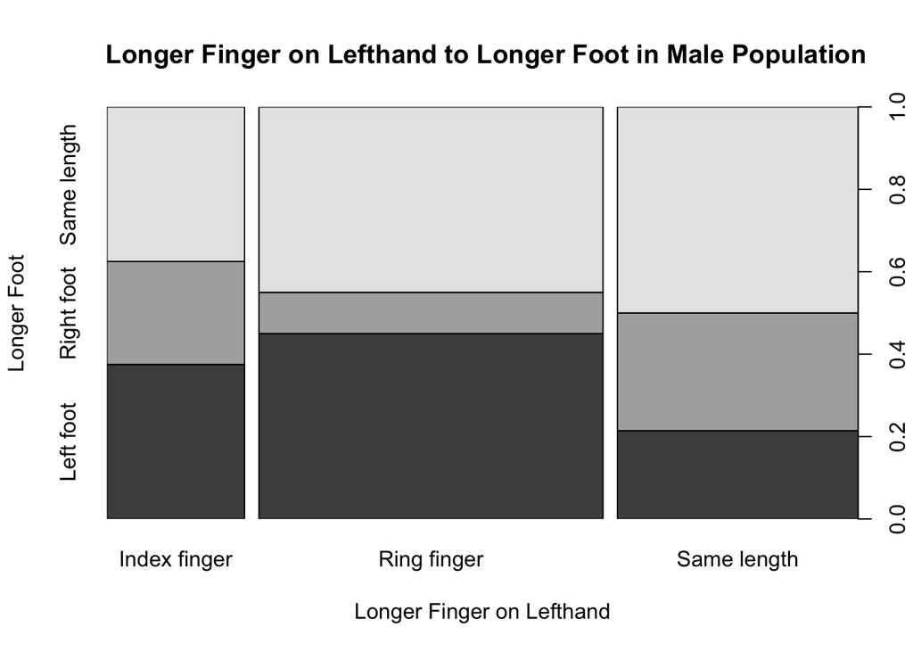

```r
Male.data <- subset(spring_2020_lab_1_data, Gender=="Male")

plot((Male.data$Longer_foot~Male.data$Longer_Finger_Lefthand),main=" Longer Finger on Lefthand to Longer Foot in Male Population", xlab="Longer Finger on Lefthand", ylab="Longer Foot")
```

From the graph, cumulatively, I see that there are twice as many male students with a longer left foot than right foot. On the other hand, there are also more students who recorded having same length feet but different length fingers than those who reported same length feet and same length fingers (organized as the lightest gray area of the graph). The data presents an association between longer foot and longer finger.

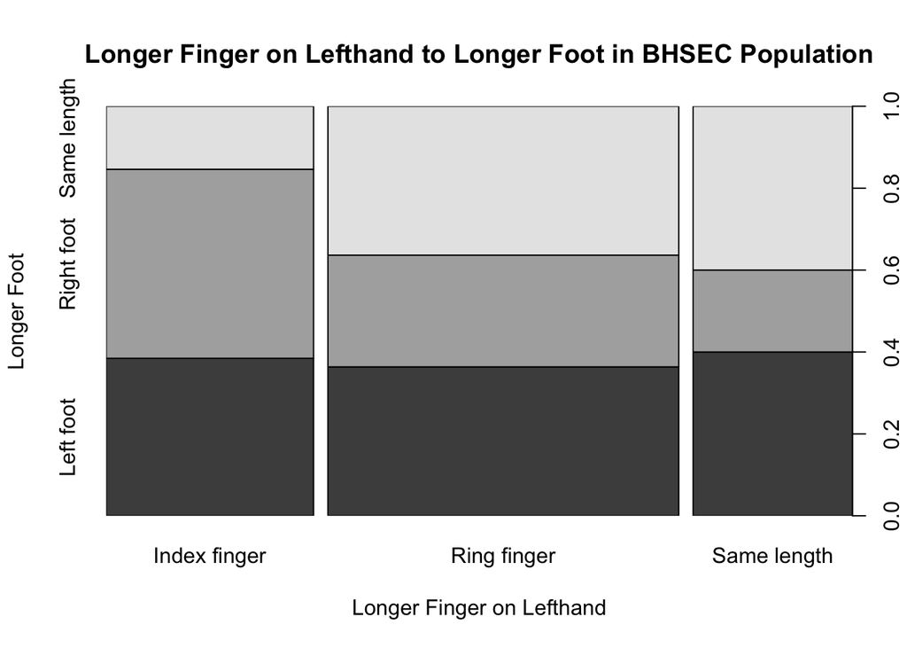

```r
BHSEC.data <- subset(spring_2020_lab_1_data, School=="BHSEC")

plot((BHSEC.data$Longer_foot~BHSEC.data$Longer_Finger_Lefthand),main="Longer Finger on Lefthand to Longer Foot in BHSEC Population", xlab="Longer Finger on Lefthand", ylab="Longer Foot")
```

In this question, I will make observations between longer foot and longer finger on the left hand within the BHSEC population. Within the population of students who have a longer left foot, right foot or same length foot, there is close to an equal fraction of BHSEC students reporting that their longer left-hand finger is the ring finger, for each of these subsets. Comparing the two data sets, there is a similar association presented in the BHSEC and the male population. The data sets are unique to one another because there isn’t one subset of each group that have similar patterns. For example, the number of students that reported the right foot as longer in BHSEC data, the numbers present in the male population data sets shrunk twice the amount.